# EDA Dataset "Mall_Customers.csv"

## Importación de Librerías

Los paquetes necesarios fueron instalados previamente mediante terminal powershell usando Anaconda con el gestor de paquetes pip

```python
import pandas as pd
import matplotlib.pyplot as plt
import seaborn as sns
```

## Lectura del data set

el dataset suministrado en la guía de aprendizaje apuntaba al sitio web de Kaggle, este a su vez refería a un repositorio en github donde se encontraba el archivo por lo que usando la función de raw podemos acceder al mismo de forma remota sin tener el archivo en nuestro equipo

```python
url = "https://raw.githubusercontent.com/SteffiPeTaffy/machineLearningAZ/master/Machine%20Learning%20A-Z%20Template%20Folder/Part%204%20-%20Clustering/Section%2025%20-%20Hierarchical%20Clustering/Mall_Customers.csv"
df = pd.read_csv(url)
```

## Visualización de columnas o variables del dataset

```python
df.info()
```

```
<class 'pandas.core.frame.DataFrame'>
RangeIndex: 200 entries, 0 to 199
Data columns (total 5 columns):
 #   Column                  Non-Null Count  Dtype
---  ------                  --------------  -----
 0   CustomerID              200 non-null    int64
 1   Genre                   200 non-null    object
 2   Age                     200 non-null    int64
 3   Annual Income (k$)      200 non-null    int64
 4   Spending Score (1-100)  200 non-null    int64
dtypes: int64(4), object(1)
memory usage: 7.9+ KB
```

## Parámetros estadísticos (Medidas de tendencia central y dispersión)

```python
df.describe()
```

|  | CustomerID | Age | Annual Income (k$) | Spending Score (1-100) |
| --- | --- | --- | --- | --- |
| count | 200.000000 | 200.000000 | 200.000000 | 200.000000 |
| mean | 100.500000 | 38.850000 | 60.560000 | 50.200000 |
| std | 57.879185 | 13.969007 | 26.264721 | 25.823522 |
| min | 1.000000 | 18.000000 | 15.000000 | 1.000000 |
| 25% | 50.750000 | 28.750000 | 41.500000 | 34.750000 |
| 50% | 100.500000 | 36.000000 | 61.500000 | 50.000000 |
| 75% | 150.250000 | 49.000000 | 78.000000 | 73.000000 |
| max | 200.000000 | 70.000000 | 137.000000 | 99.000000 |

## Identificación de datos nulos

```python
df.isnull().sum()
```

```
CustomerID                0
Genre                     0
Age                       0
Annual Income (k$)        0
Spending Score (1-100)    0
dtype: int64
```

## Distribución de variables

Se usó el dataframe general (sin omitir los ids) en labores profesionales se omitirían ids ya que no representan variables de estudio si no meros índices de registros en los siguientes pasos se omitirá para quedarnos exclusivamente con las variables de interés

```
array([[<Axes: title={'center': 'CustomerID'}>,
        <Axes: title={'center': 'Age'}>],
       [<Axes: title={'center': 'Annual Income (k$)'}>,
        <Axes: title={'center': 'Spending Score (1-100)'}>]], dtype=object)
```

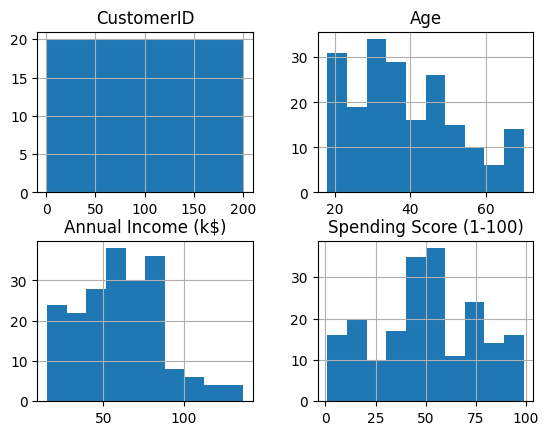

```python
df.hist()
```

## Matriz de correlación

En principio usé el método selected_dtypes para crear un dataframe derivado que incluyera datos de tipo numérico, pero despues me percaté era adecuado omitir el campo que alojaba los ids, por lo que seccioné los datos solo eligiendo los campos de interés

```python
#varnumeric_df = df.select_dtypes(include=['int64', 'float64'])
varnumeric_df = df[['Age', 'Annual Income (k$)', 'Spending Score (1-100)']]
matrixcorr= varnumeric_df.corr()
print(matrixcorr)
```

```
                             Age  Annual Income (k$)  Spending Score (1-100)
Age                     1.000000           -0.012398               -0.327227
Annual Income (k$)     -0.012398            1.000000                0.009903
Spending Score (1-100) -0.327227            0.009903                1.000000
```

## Visualización de la matriz mediante mapa de calor (Heat Map)

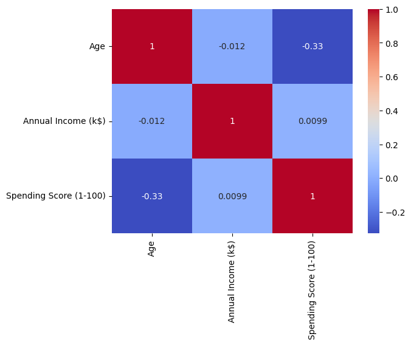

```python
sns.heatmap(matrixcorr, annot=True, cmap='coolwarm')
plt.show()
```

## Visualización de la relación entre las múltiples variables

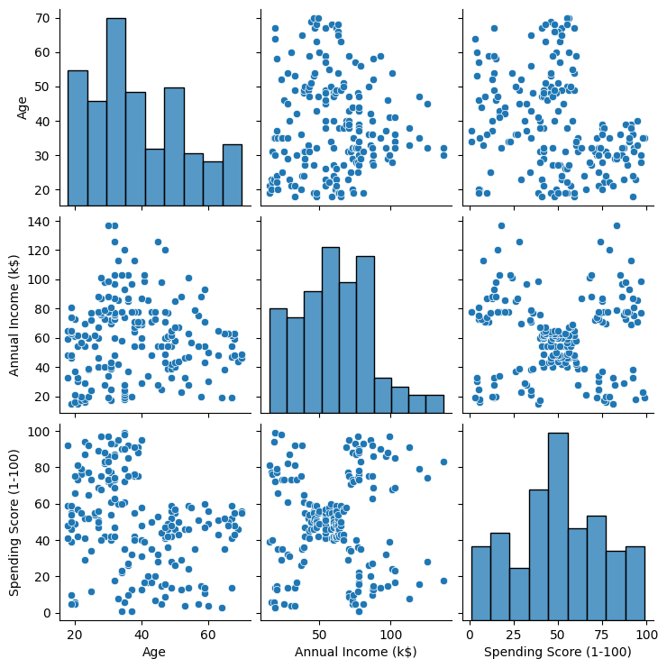

```python
sns.pairplot(varnumeric_df)
plt.show()
```